# Expected values

Statistical Inference

Brian Caffo, Jeff Leek, Roger Peng

## Expected values

- The **expected value** or **mean** of a random variable is the center of its distribution
- For discrete random variable $X$ with PMF $p(x)$, it is defined as follows
  $$E[X] = \sum_x xp(x).$$
  where the sum is taken over the possible values of $x$
- $E[X]$ represents the center of mass of a collection of locations and weights, $\{x, p(x)\}$

## Example

### Find the center of mass of the bars

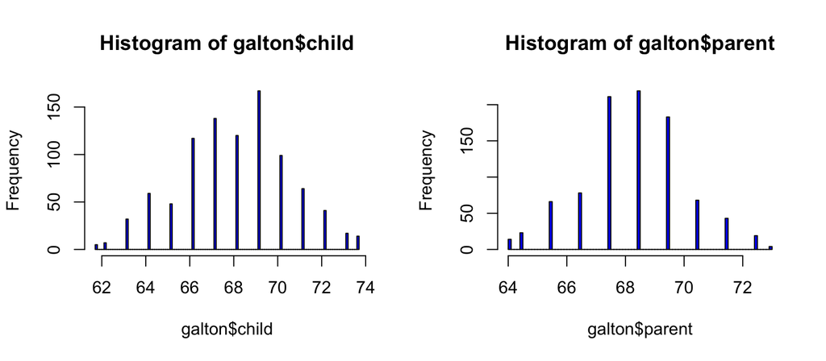

## The center of mass is the empirical mean

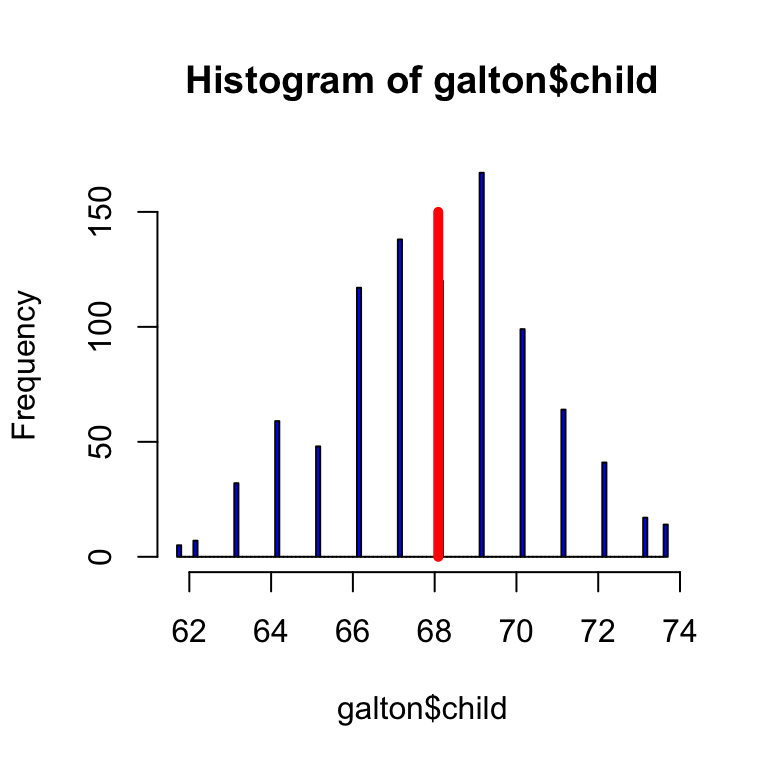

```r
  hist(galton$child,col="blue",breaks=100)
  meanChild <- mean(galton$child)
  lines(rep(meanChild,100),seq(0,150,length=100),col="red",lwd=5)
```

## Example

- Suppose that a die is rolled and $X$ is the number face up
- What is the expected value of $X$?
  $$E[X] = 1 \times \frac{1}{6} + 2 \times \frac{1}{6} +
  3 \times \frac{1}{6} + 4 \times \frac{1}{6} +
  5 \times \frac{1}{6} + 6 \times \frac{1}{6} = 3.5$$
- Again, the geometric argument makes this answer obvious without calculation.

## Continuous random variables

- For a continuous random variable, $X$, with density, $f$, the expected value is defined as follows
  $$E[X] = \mbox{the area under the function}~~~ t f(t)$$
- This definition borrows from the definition of center of mass for a continuous body

## Example

- Consider a density where $f(x) = 1$ for $x$ between zero and one
- (Is this a valid density?)
- Suppose that $X$ follows this density; what is its expected value?

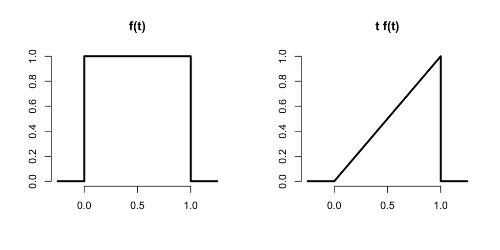

## Rules about expected values

- The expected value is a linear operator
- If $a$ and $b$ are not random and $X$ and $Y$ are two random variables then
- $E[aX + b] = a E[X] + b$
- $E[X + Y] = E[X] + E[Y]$

## Example

- You flip a coin, $X$ and simulate a uniform random number $Y$, what is the expected value of their sum?
  $$E[X + Y] = E[X] + E[Y] = .5 + .5 = 1$$
- Another example, you roll a die twice. What is the expected value of the average?
- Let $X_1$ and $X_2$ be the results of the two rolls
  $$E[(X_1 + X_2) / 2] = \frac{1}{2}(E[X_1] + E[X_2])
  = \frac{1}{2}(3.5 + 3.5) = 3.5$$

## Example

1. Let $X_i$ for $i=1,\ldots,n$ be a collection of random variables, each from a distribution with mean $\mu$
2. Calculate the expected value of the sample average of the $X_i$
   $$\begin{eqnarray*}
   E\left[ \frac{1}{n}\sum_{i=1}^n X_i\right]
   & = & \frac{1}{n} E\left[\sum_{i=1}^n X_i\right] \\
   & = & \frac{1}{n} \sum_{i=1}^n E\left[X_i\right] \\
   & = & \frac{1}{n} \sum_{i=1}^n \mu = \mu.
   \end{eqnarray*}$$

## Remark

- Therefore, the expected value of the **sample mean** is the population mean that it’s trying to estimate
- When the expected value of an estimator is what its trying to estimate, we say that the estimator is **unbiased**

## The variance

- The variance of a random variable is a measure of *spread*
- If $X$ is a random variable with mean $\mu$, the variance of $X$ is defined as

$$Var(X) = E[(X - \mu)^2]$$

the expected (squared) distance from the mean - Densities with a higher variance are more spread out than densities with a lower variance

- Convenient computational form
  $$Var(X) = E[X^2] - E[X]^2$$
- If $a$ is constant then $Var(aX) = a^2 Var(X)$
- The square root of the variance is called the **standard deviation**
- The standard deviation has the same units as $X$

## Example

- What’s the sample variance from the result of a toss of a die?
- $E[X] = 3.5$
- $E[X^2] = 1 ^ 2 \times \frac{1}{6} + 2 ^ 2 \times \frac{1}{6} + 3 ^ 2 \times \frac{1}{6} + 4 ^ 2 \times \frac{1}{6} + 5 ^ 2 \times \frac{1}{6} + 6 ^ 2 \times \frac{1}{6} = 15.17$
- $Var(X) = E[X^2] - E[X]^2 \approx 2.92$

## Example

- What’s the sample variance from the result of the toss of a coin with probability of heads (1) of $p$?
- $E[X] = 0 \times (1 - p) + 1 \times p = p$
- $E[X^2] = E[X] = p$
- $Var(X) = E[X^2] - E[X]^2 = p - p^2 = p(1 - p)$

## Interpreting variances

- Chebyshev’s inequality is useful for interpreting variances
- This inequality states that
  $$P(|X - \mu| \geq k\sigma) \leq \frac{1}{k^2}$$
- For example, the probability that a random variable lies beyond $k$ standard deviations from its mean is less than $1/k^2$
  $$\begin{eqnarray*}
  2\sigma & \rightarrow & 25\% \\
  3\sigma & \rightarrow & 11\% \\
  4\sigma & \rightarrow & 6\%
  \end{eqnarray*}$$
- Note this is only a bound; the actual probability might be quite a bit smaller

## Example

- IQs are often said to be distributed with a mean of $100$ and a sd of $15$
- What is the probability of a randomly drawn person having an IQ higher than $160$ or below $40$?
- Thus we want to know the probability of a person being more than $4$ standard deviations from the mean
- Thus Chebyshev’s inequality suggests that this will be no larger than 6%
- IQs distributions are often cited as being bell shaped, in which case this bound is very conservative
- The probability of a random draw from a bell curve being $4$ standard deviations from the mean is on the order of $10^{-5}$ (one thousandth of one percent)

## Example

- A former buzz phrase in industrial quality control is Motorola’s “Six Sigma” whereby businesses are suggested to control extreme events or rare defective parts
- Chebyshev’s inequality states that the probability of a “Six Sigma” event is less than $1/6^2 \approx 3\%$
- If a bell curve is assumed, the probability of a “six sigma” event is on the order of $10^{-9}$ (one ten millionth of a percent)